# ch11_ 데이터프레임과 시리즈(Pandas)_9-13절

```python
from statsmodels.api import datasets
iris=datasets.get_rdataset('iris').data
print(iris.shape)
iris.iloc[[0,49,50,99,100,149]]
```

```
(150, 5)
```

|  | Sepal.Length | Sepal.Width | Petal.Length | Petal.Width | Species |
| --- | --- | --- | --- | --- | --- |
| 0 | 5.1 | 3.5 | 1.4 | 0.2 | setosa |
| 49 | 5.0 | 3.3 | 1.4 | 0.2 | setosa |
| 50 | 7.0 | 3.2 | 4.7 | 1.4 | versicolor |
| 99 | 5.7 | 2.8 | 4.1 | 1.3 | versicolor |
| 100 | 6.3 | 3.3 | 6.0 | 2.5 | virginica |
| 149 | 5.9 | 3.0 | 5.1 | 1.8 | virginica |

# 9.1 groupby

cf.pivot_table

```python
# 1 그룹화 방법1
#   df.groupby(by=[그룹핑할 열]) [[함수적용해서 출력할 열들]].기초통계함수()
    # [[함수적용해서 출력할 열들]] 생략시 모든 열 적용
iris_grouped=iris.groupby(by='Species')
iris_grouped=iris.groupby(by=iris.Species)
list(iris_grouped)
```

```
[('setosa',
      Sepal.Length  Sepal.Width  Petal.Length  Petal.Width Species
  0            5.1          3.5           1.4          0.2  setosa
  1            4.9          3.0           1.4          0.2  setosa
  2            4.7          3.2           1.3          0.2  setosa
  3            4.6          3.1           1.5          0.2  setosa
  4            5.0          3.6           1.4          0.2  setosa
  5            5.4          3.9           1.7          0.4  setosa
  6            4.6          3.4           1.4          0.3  setosa
  7            5.0          3.4           1.5          0.2  setosa
  8            4.4          2.9           1.4          0.2  setosa
  9            4.9          3.1           1.5          0.1  setosa
  10           5.4          3.7           1.5          0.2  setosa
  11           4.8          3.4           1.6          0.2  setosa
  12           4.8          3.0           1.4          0.1  setosa
```

[output cut: 141 more lines]

```python
# 1) 그룹화 방법1
#    df.grauby(by=[그룹핑할 열])[[함수적용하여 출력할 열들]].기초통계함수()
    # [[함수적용하여 출력할 열들]] 생략시 모든열에 적용됨

iris_grouped = iris.groupby(by='Species')

iris_grouped = iris.groupby(by=iris.Species)
iris_grouped_sum = iris_grouped.sum()

iris_grouped_sum

iris.groupby(by='Species')[['Sepal.Length' , 'Sepal.Width']].sum() # 두가지만 출력

iris.groupby(by='Species') # 전부다 출력
```

```
<pandas.core.groupby.generic.DataFrameGroupBy object at 0x0000022BECBA1CC0>
```

```python
# setosa와 virginica의 종별 합
iris_grouped_sum .loc[['setosa' ,'virginica']]
```

| Species | Sepal.Length | Sepal.Width | Petal.Length | Petal.Width |
| --- | --- | --- | --- | --- |
| setosa | 250.3 | 171.4 | 73.1 | 12.3 |
| virginica | 329.4 | 148.7 | 277.6 | 101.3 |

```python
iris_grouped_sum.reset_index(inplace=True)
iris_grouped_sum
```

[output not shown]

```python
#
iris_grouped_sum[(iris_grouped_sum['Species']=='setosa')|
                (iris_grouped_sum['Species']=='virginica')]
```

|  | index | Species | Sepal.Length | Sepal.Width | Petal.Length | Petal.Width |
| --- | --- | --- | --- | --- | --- | --- |
| 0 | 0 | setosa | 250.3 | 171.4 | 73.1 | 12.3 |
| 2 | 2 | virginica | 329.4 | 148.7 | 277.6 | 101.3 |

```python
iris_grouped_sum[iris_grouped_sum['Species'].isin(['setosa' ,'virfinica'])]
```

|  | index | Species | Sepal.Length | Sepal.Width | Petal.Length | Petal.Width |
| --- | --- | --- | --- | --- | --- | --- |
| 0 | 0 | setosa | 250.3 | 171.4 | 73.1 | 12.3 |

```python
# 1) 그룹화 방법1-1 : 그룹핑할때 index를 컬럼으로 편입
#    df.grauby(by=[그룹핑할 열])[[함수적용하여 출력할 열들]].기초통계함수()
    # [[함수적용하여 출력할 열들]] 생략시 모든열에 적용됨

iris.groupby('Species', as_index=False).sum()
```

|  | Species | Sepal.Length | Sepal.Width | Petal.Length | Petal.Width |
| --- | --- | --- | --- | --- | --- |
| 0 | setosa | 250.3 | 171.4 | 73.1 | 12.3 |
| 1 | versicolor | 296.8 | 138.5 | 213.0 | 66.3 |
| 2 | virginica | 329.4 | 148.7 | 277.6 | 101.3 |

```python
# 1) 그룹화 방법1 : 그룹핑할때 index를 컬럼으로 편입
#    df.grauby(by=[그룹핑할 열])[[함수적용하여 출력할 열들]].기초통계함수()
    # [[함수적용하여 출력할 열들]] 생략시 모든열에 적용됨
# 2) 그룹화 방법2:
    #df.pivot_table(index='그룹화할 열' ,
                    # values=[함수적용해서 출력할 열들],
                    # aggfunc='sum')
                    #
```

```python
iris.pivot_table(index='Species',
                aggfunc='sum')
```

| Species | Petal.Length | Petal.Width | Sepal.Length | Sepal.Width |
| --- | --- | --- | --- | --- |
| setosa | 73.1 | 12.3 | 250.3 | 171.4 |
| versicolor | 213.0 | 66.3 | 296.8 | 138.5 |
| virginica | 277.6 | 101.3 | 329.4 | 148.7 |

```python
iris.pivot table?
```

```
Object `table` not found.
```

```python
iris.pivot_table(index='Species',
                 values='Sepal.Length',
                 aggfunc='count')
```

| Species | Sepal.Length |
| --- | --- |
| setosa | 50 |
| versicolor | 50 |
| virginica | 50 |

```python
iris.pivot_table(index='Species',
                 #values='Sepal.Length',
                 aggfunc='count')
```

| Species | Petal.Length | Petal.Width | Sepal.Length | Sepal.Width |
| --- | --- | --- | --- | --- |
| setosa | 50 | 50 | 50 | 50 |
| versicolor | 50 | 50 | 50 | 50 |
| virginica | 50 | 50 | 50 | 50 |

## 다중열 그룹화

```python
iris
```

|  | Sepal.Length | Sepal.Width | Petal.Length | Petal.Width | Species |
| --- | --- | --- | --- | --- | --- |
| 0 | 5.1 | 3.5 | 1.4 | 0.2 | setosa |
| 1 | 4.9 | 3.0 | 1.4 | 0.2 | setosa |
| 2 | 4.7 | 3.2 | 1.3 | 0.2 | setosa |
| 3 | 4.6 | 3.1 | 1.5 | 0.2 | setosa |
| 4 | 5.0 | 3.6 | 1.4 | 0.2 | setosa |
| ... | ... | ... | ... | ... | ... |
| 145 | 6.7 | 3.0 | 5.2 | 2.3 | virginica |
| 146 | 6.3 | 2.5 | 5.0 | 1.9 | virginica |
| 147 | 6.5 | 3.0 | 5.2 | 2.0 | virginica |
| 148 | 6.2 | 3.4 | 5.4 | 2.3 | virginica |
| 149 | 5.9 | 3.0 | 5.1 | 1.8 | virginica |

150 rows × 5 columns

```python
iris.iloc[::5]
```

|  | Sepal.Length | Sepal.Width | Petal.Length | Petal.Width | Species |
| --- | --- | --- | --- | --- | --- |
| 0 | 5.1 | 3.5 | 1.4 | 0.2 | setosa |
| 5 | 5.4 | 3.9 | 1.7 | 0.4 | setosa |
| 10 | 5.4 | 3.7 | 1.5 | 0.2 | setosa |
| 15 | 5.7 | 4.4 | 1.5 | 0.4 | setosa |
| 20 | 5.4 | 3.4 | 1.7 | 0.2 | setosa |
| 25 | 5.0 | 3.0 | 1.6 | 0.2 | setosa |
| 30 | 4.8 | 3.1 | 1.6 | 0.2 | setosa |
| 35 | 5.0 | 3.2 | 1.2 | 0.2 | setosa |
| 40 | 5.0 | 3.5 | 1.3 | 0.3 | setosa |
| 45 | 4.8 | 3.0 | 1.4 | 0.3 | setosa |
| 50 | 7.0 | 3.2 | 4.7 | 1.4 | versicolor |
| 55 | 5.7 | 2.8 | 4.5 | 1.3 | versicolor |
| 60 | 5.0 | 2.0 | 3.5 | 1.0 | versicolor |
| 65 | 6.7 | 3.1 | 4.4 | 1.4 | versicolor |
| 70 | 5.9 | 3.2 | 4.8 | 1.8 | versicolor |
| 75 | 6.6 | 3.0 | 4.4 | 1.4 | versicolor |
| 80 | 5.5 | 2.4 | 3.8 | 1.1 | versicolor |
| 85 | 6.0 | 3.4 | 4.5 | 1.6 | versicolor |
| 90 | 5.5 | 2.6 | 4.4 | 1.2 | versicolor |
| 95 | 5.7 | 3.0 | 4.2 | 1.2 | versicolor |
| 100 | 6.3 | 3.3 | 6.0 | 2.5 | virginica |
| 105 | 7.6 | 3.0 | 6.6 | 2.1 | virginica |
| 110 | 6.5 | 3.2 | 5.1 | 2.0 | virginica |
| 115 | 6.4 | 3.2 | 5.3 | 2.3 | virginica |
| 120 | 6.9 | 3.2 | 5.7 | 2.3 | virginica |
| 125 | 7.2 | 3.2 | 6.0 | 1.8 | virginica |
| 130 | 7.4 | 2.8 | 6.1 | 1.9 | virginica |
| 135 | 7.7 | 3.0 | 6.1 | 2.3 | virginica |
| 140 | 6.7 | 3.1 | 5.6 | 2.4 | virginica |
| 145 | 6.7 | 3.0 | 5.2 | 2.3 | virginica |

```python
# iris를 다중열로 그룹화하기 위해 데이터 추가(num 필드)
# 0-25, 1-25개, 2-25개, 3-25개, 4-25개, 5-25개
import numpy as np
np.array([[i]*25 for i in range(6)]).ravel()
```

```
array([0, 0, 0, 0, 0, 0, 0, 0, 0, 0, 0, 0, 0, 0, 0, 0, 0, 0, 0, 0, 0, 0,
       0, 0, 0, 1, 1, 1, 1, 1, 1, 1, 1, 1, 1, 1, 1, 1, 1, 1, 1, 1, 1, 1,
       1, 1, 1, 1, 1, 1, 2, 2, 2, 2, 2, 2, 2, 2, 2, 2, 2, 2, 2, 2, 2, 2,
       2, 2, 2, 2, 2, 2, 2, 2, 2, 3, 3, 3, 3, 3, 3, 3, 3, 3, 3, 3, 3, 3,
       3, 3, 3, 3, 3, 3, 3, 3, 3, 3, 3, 3, 4, 4, 4, 4, 4, 4, 4, 4, 4, 4,
       4, 4, 4, 4, 4, 4, 4, 4, 4, 4, 4, 4, 4, 4, 4, 5, 5, 5, 5, 5, 5, 5,
       5, 5, 5, 5, 5, 5, 5, 5, 5, 5, 5, 5, 5, 5, 5, 5, 5, 5])
```

```python
iris['num'] = np.array([[i]*25 for i in range(6)]).ravel()
iris.tail(0)

iris.iloc[::25]
iris.iloc[::10]
```

|  | Sepal.Length | Sepal.Width | Petal.Length | Petal.Width | Species | num |
| --- | --- | --- | --- | --- | --- | --- |
| 0 | 5.1 | 3.5 | 1.4 | 0.2 | setosa | 0 |
| 10 | 5.4 | 3.7 | 1.5 | 0.2 | setosa | 0 |
| 20 | 5.4 | 3.4 | 1.7 | 0.2 | setosa | 0 |
| 30 | 4.8 | 3.1 | 1.6 | 0.2 | setosa | 1 |
| 40 | 5.0 | 3.5 | 1.3 | 0.3 | setosa | 1 |
| 50 | 7.0 | 3.2 | 4.7 | 1.4 | versicolor | 2 |
| 60 | 5.0 | 2.0 | 3.5 | 1.0 | versicolor | 2 |
| 70 | 5.9 | 3.2 | 4.8 | 1.8 | versicolor | 2 |
| 80 | 5.5 | 2.4 | 3.8 | 1.1 | versicolor | 3 |
| 90 | 5.5 | 2.6 | 4.4 | 1.2 | versicolor | 3 |
| 100 | 6.3 | 3.3 | 6.0 | 2.5 | virginica | 4 |
| 110 | 6.5 | 3.2 | 5.1 | 2.0 | virginica | 4 |
| 120 | 6.9 | 3.2 | 5.7 | 2.3 | virginica | 4 |
| 130 | 7.4 | 2.8 | 6.1 | 1.9 | virginica | 5 |
| 140 | 6.7 | 3.1 | 5.6 | 2.4 | virginica | 5 |

```python
# Species별 num별 합계
r=iris.groupby(by=['Species','num']).sum()
r
```

| Species | num | Sepal.Length | Sepal.Width | Petal.Length | Petal.Width |
| --- | --- | --- | --- | --- | --- |
| setosa | 0 | 125.7 | 87.0 | 36.5 | 6.2 |
|  | 1 | 124.6 | 84.4 | 36.6 | 6.1 |
| versicolor | 2 | 150.3 | 69.4 | 107.8 | 33.6 |
|  | 3 | 146.5 | 69.1 | 105.2 | 32.7 |
| virginica | 4 | 164.4 | 73.2 | 141.0 | 51.1 |
|  | 5 | 165.0 | 75.5 | 136.6 | 50.2 |

```python
r.loc[['setosa','virginica']]
```

| Species | num | Sepal.Length | Sepal.Width | Petal.Length | Petal.Width |
| --- | --- | --- | --- | --- | --- |
| setosa | 0 | 125.7 | 87.0 | 36.5 | 6.2 |
|  | 1 | 124.6 | 84.4 | 36.6 | 6.1 |
| virginica | 4 | 164.4 | 73.2 | 141.0 | 51.1 |
|  | 5 | 165.0 | 75.5 | 136.6 | 50.2 |

```python
r.loc[[('setosa,0'),('virginica',4)]]
```

[output not shown]

```python
iris.groupby(by=['Species','num'],
             as_index=False)[['Sepal.Length','Sepal.Width']].sum()
```

|  | Species | num | Sepal.Length | Sepal.Width |
| --- | --- | --- | --- | --- |
| 0 | setosa | 0 | 125.7 | 87.0 |
| 1 | setosa | 1 | 124.6 | 84.4 |
| 2 | versicolor | 2 | 150.3 | 69.4 |
| 3 | versicolor | 3 | 146.5 | 69.1 |
| 4 | virginica | 4 | 164.4 | 73.2 |
| 5 | virginica | 5 | 165.0 | 75.5 |

```python
r.loc[['setosa' , 'virginica']]
```

| Species | num | Sepal.Length | Sepal.Width | Petal.Length | Petal.Width |
| --- | --- | --- | --- | --- | --- |
| setosa | 0 | 125.7 | 87.0 | 36.5 | 6.2 |
|  | 1 | 124.6 | 84.4 | 36.6 | 6.1 |
| virginica | 4 | 164.4 | 73.2 | 141.0 | 51.1 |
|  | 5 | 165.0 | 75.5 | 136.6 | 50.2 |

```python
r.loc[[('setosa' ,0) , ('virginica' ,4)]]
```

| Species | num | Sepal.Length | Sepal.Width | Petal.Length | Petal.Width |
| --- | --- | --- | --- | --- | --- |
| setosa | 0 | 125.7 | 87.0 | 36.5 | 6.2 |
| virginica | 4 | 164.4 | 73.2 | 141.0 | 51.1 |

```python
# Species별 , num별 합계(그룹핑할 열을 컬럼 데이터로)

iris.groupby(by=['Species' , 'num'],
             as_index=False)[['Sepal.Length' ,'Sepal.Width']].sum()
```

|  | Species | num | Sepal.Length | Sepal.Width |
| --- | --- | --- | --- | --- |
| 0 | setosa | 0 | 125.7 | 87.0 |
| 1 | setosa | 1 | 124.6 | 84.4 |
| 2 | versicolor | 2 | 150.3 | 69.4 |
| 3 | versicolor | 3 | 146.5 | 69.1 |
| 4 | virginica | 4 | 164.4 | 73.2 |
| 5 | virginica | 5 | 165.0 | 75.5 |

```python
iris.pivot_table(index=['Species' ,'num'],
                values=['Sepal.Length' ,'Sepal.Width'] ,
                aggfunc='sum')
```

| Species | num | Sepal.Length | Sepal.Width |
| --- | --- | --- | --- |
| setosa | 0 | 125.7 | 87.0 |
|  | 1 | 124.6 | 84.4 |
| versicolor | 2 | 150.3 | 69.4 |
|  | 3 | 146.5 | 69.1 |
| virginica | 4 | 164.4 | 73.2 |
|  | 5 | 165.0 | 75.5 |

```python
iris.describe()
```

|  | Sepal.Length | Sepal.Width | Petal.Length | Petal.Width | num |
| --- | --- | --- | --- | --- | --- |
| count | 150.000000 | 150.000000 | 150.000000 | 150.000000 | 150.000000 |
| mean | 5.843333 | 3.057333 | 3.758000 | 1.199333 | 2.500000 |
| std | 0.828066 | 0.435866 | 1.765298 | 0.762238 | 1.713547 |
| min | 4.300000 | 2.000000 | 1.000000 | 0.100000 | 0.000000 |
| 25% | 5.100000 | 2.800000 | 1.600000 | 0.300000 | 1.000000 |
| 50% | 5.800000 | 3.000000 | 4.350000 | 1.300000 | 2.500000 |
| 75% | 6.400000 | 3.300000 | 5.100000 | 1.800000 | 4.000000 |
| max | 7.900000 | 4.400000 | 6.900000 | 2.500000 | 5.000000 |

```python
iris.groupby('Species')[['Sepal.Length' ,
                          'Sepal.Width' ,
                          'Petal.Length' ,
                          'Petal.Width']].describe().T
```

|  | Species | setosa | versicolor | virginica |
| --- | --- | --- | --- | --- |
| Sepal.Length | count | 50.000000 | 50.000000 | 50.000000 |
|  | mean | 5.006000 | 5.936000 | 6.588000 |
|  | std | 0.352490 | 0.516171 | 0.635880 |
|  | min | 4.300000 | 4.900000 | 4.900000 |
|  | 25% | 4.800000 | 5.600000 | 6.225000 |
|  | 50% | 5.000000 | 5.900000 | 6.500000 |
|  | 75% | 5.200000 | 6.300000 | 6.900000 |
|  | max | 5.800000 | 7.000000 | 7.900000 |
| Sepal.Width | count | 50.000000 | 50.000000 | 50.000000 |
|  | mean | 3.428000 | 2.770000 | 2.974000 |
|  | std | 0.379064 | 0.313798 | 0.322497 |
|  | min | 2.300000 | 2.000000 | 2.200000 |
|  | 25% | 3.200000 | 2.525000 | 2.800000 |
|  | 50% | 3.400000 | 2.800000 | 3.000000 |
|  | 75% | 3.675000 | 3.000000 | 3.175000 |
|  | max | 4.400000 | 3.400000 | 3.800000 |
| Petal.Length | count | 50.000000 | 50.000000 | 50.000000 |
|  | mean | 1.462000 | 4.260000 | 5.552000 |
|  | std | 0.173664 | 0.469911 | 0.551895 |
|  | min | 1.000000 | 3.000000 | 4.500000 |
|  | 25% | 1.400000 | 4.000000 | 5.100000 |
|  | 50% | 1.500000 | 4.350000 | 5.550000 |
|  | 75% | 1.575000 | 4.600000 | 5.875000 |
|  | max | 1.900000 | 5.100000 | 6.900000 |
| Petal.Width | count | 50.000000 | 50.000000 | 50.000000 |
|  | mean | 0.246000 | 1.326000 | 2.026000 |
|  | std | 0.105386 | 0.197753 | 0.274650 |
|  | min | 0.100000 | 1.000000 | 1.400000 |
|  | 25% | 0.200000 | 1.200000 | 1.800000 |
|  | 50% | 0.200000 | 1.300000 | 2.000000 |
|  | 75% | 0.300000 | 1.500000 | 2.300000 |
|  | max | 0.600000 | 1.800000 | 2.500000 |

```python
g = iris.groupby('Species')[['Sepal.Length' ,
                          'Sepal.Width' ,
                          'Petal.Length' ,
                          'Petal.Width']].sum()

g
```

| Species | Sepal.Length | Sepal.Width | Petal.Length | Petal.Width |
| --- | --- | --- | --- | --- |
| setosa | 250.3 | 171.4 | 73.1 | 12.3 |
| versicolor | 296.8 | 138.5 | 213.0 | 66.3 |
| virginica | 329.4 | 148.7 | 277.6 | 101.3 |

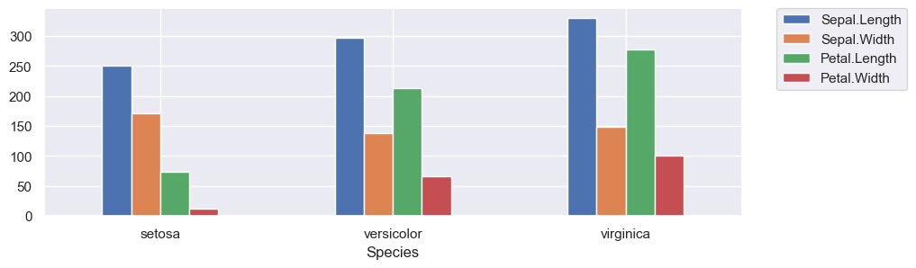

```python
import matplotlib.pyplot as plt
g.plot(kind='bar',figsize=(10,3),rot=0)
# 법례를 밖으로
plt.legend(bbox_to_anchor=(1.05 ,1) , loc=2 , borderaxespad=0.)
plt.show()
```

https://stackoverflow.com/questi ons/30490740/move legend outside figure in seaborn tsplot : 범례사용(시각화 20쪽)

## 9.2 그룹간 데이터 처리

```python
iris_grouped=iris.groupby('Species')
iris_grouped
```

```
<pandas.core.groupby.generic.DataFrameGroupBy object at 0x0000022BF5371900>
```

```python
for speciesname, group in iris_grouped:
    print(speciesname)
    display(group.head(3))
```

```
setosa
```

|  | Sepal.Length | Sepal.Width | Petal.Length | Petal.Width | Species | num |
| --- | --- | --- | --- | --- | --- | --- |
| 0 | 5.1 | 3.5 | 1.4 | 0.2 | setosa | 0 |
| 1 | 4.9 | 3.0 | 1.4 | 0.2 | setosa | 0 |
| 2 | 4.7 | 3.2 | 1.3 | 0.2 | setosa | 0 |

```
versicolor
```

|  | Sepal.Length | Sepal.Width | Petal.Length | Petal.Width | Species | num |
| --- | --- | --- | --- | --- | --- | --- |
| 50 | 7.0 | 3.2 | 4.7 | 1.4 | versicolor | 2 |
| 51 | 6.4 | 3.2 | 4.5 | 1.5 | versicolor | 2 |
| 52 | 6.9 | 3.1 | 4.9 | 1.5 | versicolor | 2 |

```
virginica
```

|  | Sepal.Length | Sepal.Width | Petal.Length | Petal.Width | Species | num |
| --- | --- | --- | --- | --- | --- | --- |
| 100 | 6.3 | 3.3 | 6.0 | 2.5 | virginica | 4 |
| 101 | 5.8 | 2.7 | 5.1 | 1.9 | virginica | 4 |
| 102 | 7.1 | 3.0 | 5.9 | 2.1 | virginica | 4 |

```python
for speciesname, group in iris_grouped:
    print(speciesname)
    display(group.sample(3).sort_index())
```

```
setosa
```

|  | Sepal.Length | Sepal.Width | Petal.Length | Petal.Width | Species | num |
| --- | --- | --- | --- | --- | --- | --- |
| 11 | 4.8 | 3.4 | 1.6 | 0.2 | setosa | 0 |
| 12 | 4.8 | 3.0 | 1.4 | 0.1 | setosa | 0 |
| 31 | 5.4 | 3.4 | 1.5 | 0.4 | setosa | 1 |

```
versicolor
```

|  | Sepal.Length | Sepal.Width | Petal.Length | Petal.Width | Species | num |
| --- | --- | --- | --- | --- | --- | --- |
| 66 | 5.6 | 3.0 | 4.5 | 1.5 | versicolor | 2 |
| 73 | 6.1 | 2.8 | 4.7 | 1.2 | versicolor | 2 |
| 99 | 5.7 | 2.8 | 4.1 | 1.3 | versicolor | 3 |

```
virginica
```

|  | Sepal.Length | Sepal.Width | Petal.Length | Petal.Width | Species | num |
| --- | --- | --- | --- | --- | --- | --- |
| 110 | 6.5 | 3.2 | 5.1 | 2.0 | virginica | 4 |
| 135 | 7.7 | 3.0 | 6.1 | 2.3 | virginica | 5 |
| 149 | 5.9 | 3.0 | 5.1 | 1.8 | virginica | 5 |

```python
for speciesname, group in iris_grouped:
    print(speciesname)
    display(group.iloc[[0,10,20,30,40]])
```

```
setosa
```

|  | Sepal.Length | Sepal.Width | Petal.Length | Petal.Width | Species | num |
| --- | --- | --- | --- | --- | --- | --- |
| 0 | 5.1 | 3.5 | 1.4 | 0.2 | setosa | 0 |
| 10 | 5.4 | 3.7 | 1.5 | 0.2 | setosa | 0 |
| 20 | 5.4 | 3.4 | 1.7 | 0.2 | setosa | 0 |
| 30 | 4.8 | 3.1 | 1.6 | 0.2 | setosa | 1 |
| 40 | 5.0 | 3.5 | 1.3 | 0.3 | setosa | 1 |

```
versicolor
```

|  | Sepal.Length | Sepal.Width | Petal.Length | Petal.Width | Species | num |
| --- | --- | --- | --- | --- | --- | --- |
| 50 | 7.0 | 3.2 | 4.7 | 1.4 | versicolor | 2 |
| 60 | 5.0 | 2.0 | 3.5 | 1.0 | versicolor | 2 |
| 70 | 5.9 | 3.2 | 4.8 | 1.8 | versicolor | 2 |
| 80 | 5.5 | 2.4 | 3.8 | 1.1 | versicolor | 3 |
| 90 | 5.5 | 2.6 | 4.4 | 1.2 | versicolor | 3 |

```
virginica
```

|  | Sepal.Length | Sepal.Width | Petal.Length | Petal.Width | Species | num |
| --- | --- | --- | --- | --- | --- | --- |
| 100 | 6.3 | 3.3 | 6.0 | 2.5 | virginica | 4 |
| 110 | 6.5 | 3.2 | 5.1 | 2.0 | virginica | 4 |
| 120 | 6.9 | 3.2 | 5.7 | 2.3 | virginica | 4 |
| 130 | 7.4 | 2.8 | 6.1 | 1.9 | virginica | 5 |
| 140 | 6.7 | 3.1 | 5.6 | 2.4 | virginica | 5 |

## 9.3 데이터프레임 그룹 인덱싱

```python
iris.groupby('Species').take([0,10,20,30,40])
```

| Species |  | Sepal.Length | Sepal.Width | Petal.Length | Petal.Width | num |
| --- | --- | --- | --- | --- | --- | --- |
| setosa | 0 | 5.1 | 3.5 | 1.4 | 0.2 | 0 |
|  | 10 | 5.4 | 3.7 | 1.5 | 0.2 | 0 |
|  | 20 | 5.4 | 3.4 | 1.7 | 0.2 | 0 |
|  | 30 | 4.8 | 3.1 | 1.6 | 0.2 | 1 |
|  | 40 | 5.0 | 3.5 | 1.3 | 0.3 | 1 |
| versicolor | 50 | 7.0 | 3.2 | 4.7 | 1.4 | 2 |
|  | 60 | 5.0 | 2.0 | 3.5 | 1.0 | 2 |
|  | 70 | 5.9 | 3.2 | 4.8 | 1.8 | 2 |
|  | 80 | 5.5 | 2.4 | 3.8 | 1.1 | 3 |
|  | 90 | 5.5 | 2.6 | 4.4 | 1.2 | 3 |
| virginica | 100 | 6.3 | 3.3 | 6.0 | 2.5 | 4 |
|  | 110 | 6.5 | 3.2 | 5.1 | 2.0 | 4 |
|  | 120 | 6.9 | 3.2 | 5.7 | 2.3 | 4 |
|  | 130 | 7.4 | 2.8 | 6.1 | 1.9 | 5 |
|  | 140 | 6.7 | 3.1 | 5.6 | 2.4 | 5 |

# 10절 데이터 구조 변경

-와이드포맷<->롱포맷 -판다스 공식 문서ㅡ

```python
airquality = datasets.get_rdataset('airquality').data
airquality
```

|  | Ozone | Solar.R | Wind | Temp | Month | Day |
| --- | --- | --- | --- | --- | --- | --- |
| 0 | 41.0 | 190.0 | 7.4 | 67 | 5 | 1 |
| 1 | 36.0 | 118.0 | 8.0 | 72 | 5 | 2 |
| 2 | 12.0 | 149.0 | 12.6 | 74 | 5 | 3 |
| 3 | 18.0 | 313.0 | 11.5 | 62 | 5 | 4 |
| 4 | NaN | NaN | 14.3 | 56 | 5 | 5 |
| ... | ... | ... | ... | ... | ... | ... |
| 148 | 30.0 | 193.0 | 6.9 | 70 | 9 | 26 |
| 149 | NaN | 145.0 | 13.2 | 77 | 9 | 27 |
| 150 | 14.0 | 191.0 | 14.3 | 75 | 9 | 28 |
| 151 | 18.0 | 131.0 | 8.0 | 76 | 9 | 29 |
| 152 | 20.0 | 223.0 | 11.5 | 68 | 9 | 30 |

153 rows × 6 columns

## 10.1 melt를 이용한 언피벗팅(와이드포맷->롱포맷)

```python
airquality.melt(id_vars=['Month','Day']).sort_values(by=['Month','Day'])
```

|  | Month | Day | variable | value |
| --- | --- | --- | --- | --- |
| 0 | 5 | 1 | Ozone | 41.0 |
| 153 | 5 | 1 | Solar.R | 190.0 |
| 306 | 5 | 1 | Wind | 7.4 |
| 459 | 5 | 1 | Temp | 67.0 |
| 1 | 5 | 2 | Ozone | 36.0 |
| ... | ... | ... | ... | ... |
| 610 | 9 | 29 | Temp | 76.0 |
| 152 | 9 | 30 | Ozone | 20.0 |
| 305 | 9 | 30 | Solar.R | 223.0 |
| 458 | 9 | 30 | Wind | 11.5 |
| 611 | 9 | 30 | Temp | 68.0 |

612 rows × 4 columns

```python
airquality.melt(id_vars=['Month' , 'Day'],
               var_name='변수명' ,
               value_name='값').sort_values(by=['Month' ,'Day'])
```

|  | Month | Day | 변수명 | 값 |
| --- | --- | --- | --- | --- |
| 0 | 5 | 1 | Ozone | 41.0 |
| 153 | 5 | 1 | Solar.R | 190.0 |
| 306 | 5 | 1 | Wind | 7.4 |
| 459 | 5 | 1 | Temp | 67.0 |
| 1 | 5 | 2 | Ozone | 36.0 |
| ... | ... | ... | ... | ... |
| 610 | 9 | 29 | Temp | 76.0 |
| 152 | 9 | 30 | Ozone | 20.0 |
| 305 | 9 | 30 | Solar.R | 223.0 |
| 458 | 9 | 30 | Wind | 11.5 |
| 611 | 9 | 30 | Temp | 68.0 |

612 rows × 4 columns

```python
airquality_melted = airquality.melt(id_vars=['Month' , 'Day'],
               var_name='변수명' ,
               value_name='값').sort_values(by=['Month' ,'Day'])

airquality_melted.reset_index(drop=True , inplace=True)
airquality_melted
```

|  | Month | Day | 변수명 | 값 |
| --- | --- | --- | --- | --- |
| 0 | 5 | 1 | Ozone | 41.0 |
| 1 | 5 | 1 | Solar.R | 190.0 |
| 2 | 5 | 1 | Wind | 7.4 |
| 3 | 5 | 1 | Temp | 67.0 |
| 4 | 5 | 2 | Ozone | 36.0 |
| ... | ... | ... | ... | ... |
| 607 | 9 | 29 | Temp | 76.0 |
| 608 | 9 | 30 | Ozone | 20.0 |
| 609 | 9 | 30 | Solar.R | 223.0 |
| 610 | 9 | 30 | Wind | 11.5 |
| 611 | 9 | 30 | Temp | 68.0 |

612 rows × 4 columns

```python
airquality_melted.pivot_table(index=['Month', 'Day'],
                             columns='변수명',
                             values='값')
```

| Month | 변수명 Day | Ozone | Solar.R | Temp | Wind |
| --- | --- | --- | --- | --- | --- |
| 5 | 1 | 41.0 | 190.0 | 67.0 | 7.4 |
|  | 2 | 36.0 | 118.0 | 72.0 | 8.0 |
|  | 3 | 12.0 | 149.0 | 74.0 | 12.6 |
|  | 4 | 18.0 | 313.0 | 62.0 | 11.5 |
|  | 5 | NaN | NaN | 56.0 | 14.3 |
| ... | ... | ... | ... | ... | ... |
| 9 | 26 | 30.0 | 193.0 | 70.0 | 6.9 |
|  | 27 | NaN | 145.0 | 77.0 | 13.2 |
|  | 28 | 14.0 | 191.0 | 75.0 | 14.3 |
|  | 29 | 18.0 | 131.0 | 76.0 | 8.0 |
|  | 30 | 20.0 | 223.0 | 68.0 | 11.5 |

153 rows × 4 columns

```python
airquality2=airquality_melted.pivot_table(index=['Month', 'Day'],
                             columns='변수명',
                             values='값')
airquality2.head()
```

| Month | 변수명 Day | Ozone | Solar.R | Temp | Wind |
| --- | --- | --- | --- | --- | --- |
| 5 | 1 | 41.0 | 190.0 | 67.0 | 7.4 |
|  | 2 | 36.0 | 118.0 | 72.0 | 8.0 |
|  | 3 | 12.0 | 149.0 | 74.0 | 12.6 |
|  | 4 | 18.0 | 313.0 | 62.0 | 11.5 |
|  | 5 | NaN | NaN | 56.0 | 14.3 |

```python
airquality2=airquality_melted.pivot_table(index=['Month', 'Day'],
                             columns='변수명',
                             values='값')
airquality2.reset_index()
```

| 변수명 | Month | Day | Ozone | Solar.R | Temp | Wind |
| --- | --- | --- | --- | --- | --- | --- |
| 0 | 5 | 1 | 41.0 | 190.0 | 67.0 | 7.4 |
| 1 | 5 | 2 | 36.0 | 118.0 | 72.0 | 8.0 |
| 2 | 5 | 3 | 12.0 | 149.0 | 74.0 | 12.6 |
| 3 | 5 | 4 | 18.0 | 313.0 | 62.0 | 11.5 |
| 4 | 5 | 5 | NaN | NaN | 56.0 | 14.3 |
| ... | ... | ... | ... | ... | ... | ... |
| 148 | 9 | 26 | 30.0 | 193.0 | 70.0 | 6.9 |
| 149 | 9 | 27 | NaN | 145.0 | 77.0 | 13.2 |
| 150 | 9 | 28 | 14.0 | 191.0 | 75.0 | 14.3 |
| 151 | 9 | 29 | 18.0 | 131.0 | 76.0 | 8.0 |
| 152 | 9 | 30 | 20.0 | 223.0 | 68.0 | 11.5 |

153 rows × 6 columns

```python
airquality2=airquality_melted.pivot_table(index=['Month', 'Day'],
                             columns='변수명',
                             values='값')
airquality2=airquality_melted.pivot_table(index=['Month', 'Day'],
                             columns='변수명',
                             values='값')
airquality2.reset_index(inplace=True)
```

```python
airquality2.columns.name=None
airquality2.head()
```

|  | Month | Day | Ozone | Solar.R | Temp | Wind |
| --- | --- | --- | --- | --- | --- | --- |
| 0 | 5 | 1 | 41.0 | 190.0 | 67.0 | 7.4 |
| 1 | 5 | 2 | 36.0 | 118.0 | 72.0 | 8.0 |
| 2 | 5 | 3 | 12.0 | 149.0 | 74.0 | 12.6 |
| 3 | 5 | 4 | 18.0 | 313.0 | 62.0 | 11.5 |
| 4 | 5 | 5 | NaN | NaN | 56.0 | 14.3 |

# 11절 데이터프레임에 함수 적용시키기

-apply(func,axis): (데이터프레임이나 시리즈 모두 적용 가능) -applymap(func): 각 요소별로 적용(데이터프레임에서만 가능) -map(func):각 요소별로 적용(1차원 시리즈에서만 가능)

## 11. apply

```python
# ex1. 1차원 시리즈에 apply 사용
import pandas as pd
member=pd.read_csv('data/ch11_member.csv',comment='#')
member
```

|  | Name | Age | Email | Address | Birth |
| --- | --- | --- | --- | --- | --- |
| 0 | 홍길동 | 20 | hong@hong.com | 서울시 강동구 | 1999-01-01 |
| 1 | 홍길서 | 30 | seo@hong.com | 서울시 중구 | 1999-12-01 |
| 2 | 홍길남 | 21 | nam@hong.com | 서울시 강동구 | 1999-11-01 |
| 3 | 홍길북 | 22 | buk@hong.com | 서울시 관악구 | 1999-05-01 |
| 4 | 홍길중 | 23 | mid@hong.com | 부산시 중구 | 1999-01-30 |

```python
# 1999-01-30 문자를 1999숫자로 return
def parse_year(datestr):
    return int(datestr.split('-')[0])
parse_year("1999-01-30")
```

```
1999
```

```python
# 1999-01-30 문자를 1999숫자로 return
def parse_year(datestr):
    return int(datestr.split('-')[1])
parse_year=lambda datestr:int(datestr.split('-')[1])
parse_year("1999-01-30")
```

```
1
```

```python
member['Birth'].apply(lambda datestr : int(datestr.split('-')[0]))
```

```
0    1999
1    1999
2    1999
3    1999
4    1999
Name: Birth, dtype: int64
```

```python
member['년'] = member['Birth'].apply(lambda datestr : int(datestr.split('-')[0]))

member
```

|  | Name | Age | Email | Address | Birth | 년 |
| --- | --- | --- | --- | --- | --- | --- |
| 0 | 홍길동 | 20 | hong@hong.com | 서울시 강동구 | 1999-01-01 | 1999 |
| 1 | 홍길서 | 30 | seo@hong.com | 서울시 중구 | 1999-12-01 | 1999 |
| 2 | 홍길남 | 21 | nam@hong.com | 서울시 강동구 | 1999-11-01 | 1999 |
| 3 | 홍길북 | 22 | buk@hong.com | 서울시 관악구 | 1999-05-01 | 1999 |
| 4 | 홍길중 | 23 | mid@hong.com | 부산시 중구 | 1999-01-30 | 1999 |

```python
member['Birth']
```

```
0    1999-01-01
1    1999-12-01
2    1999-11-01
3    1999-05-01
4    1999-01-30
Name: Birth, dtype: object
```

```python
member['년'] = member['Birth'].apply(lambda datestr : int(datestr.split('-')[0]))
member['월'] = member['Birth'].apply(lambda datestr : int(datestr.split('-')[1]))
member
```

|  | Name | Age | Email | Address | Birth | 년 | 월 |
| --- | --- | --- | --- | --- | --- | --- | --- |
| 0 | 홍길동 | 20 | hong@hong.com | 서울시 강동구 | 1999-01-01 | 1999 | 1 |
| 1 | 홍길서 | 30 | seo@hong.com | 서울시 중구 | 1999-12-01 | 1999 | 12 |
| 2 | 홍길남 | 21 | nam@hong.com | 서울시 강동구 | 1999-11-01 | 1999 | 11 |
| 3 | 홍길북 | 22 | buk@hong.com | 서울시 관악구 | 1999-05-01 | 1999 | 5 |
| 4 | 홍길중 | 23 | mid@hong.com | 부산시 중구 | 1999-01-30 | 1999 | 1 |

# ex2. 2차원 데이터프레임에 apply(func,axis) 사용

%ls ""

```python
df_last=pd.read_csv(r'data\부동산\주택도시보증공사_전국 신규 민간아파트 분양가격 동향_20241231.csv' ,
                   encoding='cp949')
df_last.head()
```

|  | 지역명 | 규모구분 | 연도 | 월 | 분양가격(제곱미터) |
| --- | --- | --- | --- | --- | --- |
| 0 | 서울 | 모든면적 | 2015 | 10 | 5841 |
| 1 | 서울 | 전용면적 60제곱미터이하 | 2015 | 10 | 5652 |
| 2 | 서울 | 전용면적 60제곱미터초과 85제곱미터이하 | 2015 | 10 | 5882 |
| 3 | 서울 | 전용면적 85제곱미터초과 102제곱미터이하 | 2015 | 10 | 5721 |
| 4 | 서울 | 전용면적 102제곱미터초과 | 2015 | 10 | 5879 |

```python
row = df_last.iloc[0]
row
```

```
지역명             서울
규모구분          모든면적
연도            2015
월               10
분양가격(제곱미터)    5841
Name: 0, dtype: object
```

```python
row.지역명 , row['지역명']
```

```
('서울', '서울')
```

```python
def year_month(series):
    return str(series['연도'])+'년'+str(series['월'])+'월'
year_month(df_last.iloc[300])
```

```
'2016년1월'
```

```python
df_last['연도월']=\
    df_last.apply(lambda series:str(series['연도'])+'년'+str(series['월'])+'월', axis=1)

df_last.head()
```

|  | 지역명 | 규모구분 | 연도 | 월 | 분양가격(제곱미터) | 연도월 |
| --- | --- | --- | --- | --- | --- | --- |
| 0 | 서울 | 모든면적 | 2015 | 10 | 5841 | 2015년10월 |
| 1 | 서울 | 전용면적 60제곱미터이하 | 2015 | 10 | 5652 | 2015년10월 |
| 2 | 서울 | 전용면적 60제곱미터초과 85제곱미터이하 | 2015 | 10 | 5882 | 2015년10월 |
| 3 | 서울 | 전용면적 85제곱미터초과 102제곱미터이하 | 2015 | 10 | 5721 | 2015년10월 |
| 4 | 서울 | 전용면적 102제곱미터초과 | 2015 | 10 | 5879 | 2015년10월 |

## 11.2 applymap

```python
import seaborn as sns
iris = sns.load_dataset('iris')
X = iris.iloc[: , :-1]
X.sample()
```

|  | sepal_length | sepal_width | petal_length | petal_width |
| --- | --- | --- | --- | --- |
| 92 | 5.8 | 2.6 | 4.0 | 1.2 |

```python
X.applymap(lambda x : x**2).head()
```

|  | sepal_length | sepal_width | petal_length | petal_width |
| --- | --- | --- | --- | --- |
| 0 | 26.01 | 12.25 | 1.96 | 0.04 |
| 1 | 24.01 | 9.00 | 1.96 | 0.04 |
| 2 | 22.09 | 10.24 | 1.69 | 0.04 |
| 3 | 21.16 | 9.61 | 2.25 | 0.04 |
| 4 | 25.00 | 12.96 | 1.96 | 0.04 |

```python
import numpy as np
X.applymap(np.round)
```

|  | sepal_length | sepal_width | petal_length | petal_width |
| --- | --- | --- | --- | --- |
| 0 | 5.0 | 4.0 | 1.0 | 0.0 |
| 1 | 5.0 | 3.0 | 1.0 | 0.0 |
| 2 | 5.0 | 3.0 | 1.0 | 0.0 |
| 3 | 5.0 | 3.0 | 2.0 | 0.0 |
| 4 | 5.0 | 4.0 | 1.0 | 0.0 |
| ... | ... | ... | ... | ... |
| 145 | 7.0 | 3.0 | 5.0 | 2.0 |
| 146 | 6.0 | 2.0 | 5.0 | 2.0 |
| 147 | 6.0 | 3.0 | 5.0 | 2.0 |
| 148 | 6.0 | 3.0 | 5.0 | 2.0 |
| 149 | 6.0 | 3.0 | 5.0 | 2.0 |

150 rows × 4 columns

### ※ melt() 및 함수 적용하기 연습예제 (와이드포맷 -> 롱포멧 , pd.concat)

- 와이드포맷 ==> 롱포맷
- 2013년 12월 ==> 2023과 12나눠 '연도'와 '월'컬럼 (apply, map)
- 평당분양가격 /3.3, 컬럼명 조정=> new_first
- df_last['규모구분']=='모든 면적' 추출==> new_last
- pd.concat([new_first,new_last])

```python
# 2013년 ~2015년 8월(와이드 포맷)

df_first=pd.read_csv(r'data/부동산/전국 평균 평당 분양가격(2013년 9월부터 2015년 8월까지).csv' ,
                   encoding='cp949')
df_first
```

|  | 지역 | 2013년12월 | 2014년1월 | 2014년2월 | 2014년3월 | 2014년4월 | 2014년5월 | 2014년6월 | 2014년7월 | 2014년8월 | 2014년9월 | 2014년10월 | 2014년11월 | 2014년12월 | 2015년1월 | 2015년2월 | 2015년3월 | 2015년4월 | 2015년5월 | 2015년6월 | 2015년7월 | 2015년8월 |
| --- | --- | --- | --- | --- | --- | --- | --- | --- | --- | --- | --- | --- | --- | --- | --- | --- | --- | --- | --- | --- | --- | --- |
| 0 | 서울 | 18189 | 17925 | 17925 | 18016 | 18098 | 19446 | 18867 | 18742 | 19274 | 19404 | 19759 | 20242 | 20269 | 20670 | 20670 | 19415 | 18842 | 18367 | 18374 | 18152 | 18443 |
| 1 | 부산 | 8111 | 8111 | 9078 | 8965 | 9402 | 9501 | 9453 | 9457 | 9411 | 9258 | 9110 | 9208 | 9208 | 9204 | 9235 | 9279 | 9327 | 9345 | 9515 | 9559 | 9581 |
| 2 | 대구 | 8080 | 8080 | 8077 | 8101 | 8267 | 8274 | 8360 | 8360 | 8370 | 8449 | 8403 | 8439 | 8253 | 8327 | 8416 | 8441 | 8446 | 8568 | 8542 | 8542 | 8795 |
| 3 | 인천 | 10204 | 10204 | 10408 | 10408 | 10000 | 9844 | 10058 | 9974 | 9973 | 9973 | 10016 | 10020 | 10020 | 10017 | 9876 | 9876 | 9938 | 10551 | 10443 | 10443 | 10449 |
| 4 | 광주 | 6098 | 7326 | 7611 | 7346 | 7346 | 7523 | 7659 | 7612 | 7622 | 7802 | 7707 | 7752 | 7748 | 7752 | 7756 | 7861 | 7914 | 7877 | 7881 | 8089 | 8231 |
| 5 | 대전 | 8321 | 8321 | 8321 | 8341 | 8341 | 8341 | 8333 | 8333 | 8333 | 8048 | 8038 | 8067 | 8067 | 8067 | 8067 | 8067 | 8145 | 8272 | 8079 | 8079 | 8079 |
| 6 | 울산 | 8090 | 8090 | 8090 | 8153 | 8153 | 8153 | 8153 | 8153 | 8493 | 8493 | 8627 | 8891 | 8891 | 8526 | 8526 | 8629 | 9380 | 9192 | 9190 | 9190 | 9215 |
| 7 | 경기 | 10855 | 10855 | 10791 | 10784 | 10876 | 10646 | 10266 | 10124 | 10134 | 10501 | 10397 | 10356 | 10379 | 10391 | 10355 | 10469 | 10684 | 10685 | 10573 | 10518 | 10573 |
| 8 | 세종 | 7601 | 7600 | 7532 | 7814 | 7908 | 7934 | 8067 | 8067 | 8141 | 8282 | 8527 | 8592 | 8560 | 8560 | 8560 | 8555 | 8546 | 8546 | 8671 | 8669 | 8695 |
| 9 | 강원 | 6230 | 6230 | 6230 | 6141 | 6373 | 6350 | 6350 | 6268 | 6268 | 6419 | 6631 | 6365 | 6365 | 6348 | 6350 | 6182 | 6924 | 6846 | 6986 | 7019 | 7008 |
| 10 | 충북 | 6589 | 6589 | 6611 | 6625 | 6678 | 6598 | 6587 | 6586 | 6586 | 6584 | 6529 | 6724 | 6743 | 6749 | 6747 | 6783 | 6790 | 6805 | 6682 | 6601 | 6603 |
| 11 | 충남 | 6365 | 6365 | 6379 | 6287 | 6552 | 6591 | 6644 | 6805 | 6914 | 6882 | 6831 | 6940 | 6989 | 6976 | 6980 | 7161 | 7017 | 6975 | 6939 | 6935 | 6942 |
| 12 | 전북 | 6282 | 6281 | 5946 | 5966 | 6277 | 6306 | 6351 | 6319 | 6436 | 6719 | 6581 | 6583 | 6583 | 6583 | 6583 | 6542 | 6551 | 6556 | 6601 | 6750 | 6580 |
| 13 | 전남 | 5678 | 5678 | 5678 | 5696 | 5736 | 5656 | 5609 | 5780 | 5685 | 5804 | 5753 | 5768 | 5784 | 5784 | 5833 | 5825 | 5940 | 6050 | 6243 | 6286 | 6289 |
| 14 | 경북 | 6168 | 6168 | 6234 | 6317 | 6412 | 6409 | 6554 | 6556 | 6563 | 6577 | 6778 | 6881 | 6989 | 6992 | 6953 | 6997 | 7006 | 6966 | 6887 | 7035 | 7037 |
| 15 | 경남 | 6473 | 6485 | 6502 | 6610 | 6599 | 6610 | 6615 | 6613 | 6606 | 6767 | 6881 | 7125 | 7332 | 7592 | 7588 | 7668 | 7683 | 7717 | 7715 | 7723 | 7665 |
| 16 | 제주 | 7674 | 7900 | 7900 | 7900 | 7900 | 7900 | 7914 | 7914 | 7914 | 7833 | 7724 | 7724 | 7739 | 7739 | 7739 | 7826 | 7285 | 7285 | 7343 | 7343 | 7343 |

```python
# 2013년~2015년 (와이드포맷)
import pandas as pd
df_first=pd.read_csv(r'data\부동산\주택도시보증공사_전국 신규 민간아파트 분양가격 동향_20241231.csv' ,
                   encoding='cp949')
print(df_first.shape)
df_first.head(1)
```

[output not shown]

[output cut: 24 more lines]

[output not shown]

```python
# 2015년 10월 ~2024년 (롱포맷드)

df_last=pd.read_csv(r'data\부동산\주택도시보증공사_전국 신규 민간아파트 분양가격 동향_20241231.csv' ,
                   encoding='cp949')
df_last
```

|  | 지역명 | 규모구분 | 연도 | 월 | 분양가격(제곱미터) |
| --- | --- | --- | --- | --- | --- |
| 0 | 서울 | 모든면적 | 2015 | 10 | 5841 |
| 1 | 서울 | 전용면적 60제곱미터이하 | 2015 | 10 | 5652 |
| 2 | 서울 | 전용면적 60제곱미터초과 85제곱미터이하 | 2015 | 10 | 5882 |
| 3 | 서울 | 전용면적 85제곱미터초과 102제곱미터이하 | 2015 | 10 | 5721 |
| 4 | 서울 | 전용면적 102제곱미터초과 | 2015 | 10 | 5879 |
| ... | ... | ... | ... | ... | ... |
| 9090 | 제주 | 모든면적 | 2024 | 8 | 7703 |
| 9091 | 제주 | 전용면적 60제곱미터이하 | 2024 | 8 | NaN |
| 9092 | 제주 | 전용면적 60제곱미터초과 85제곱미터이하 | 2024 | 8 | 7515 |
| 9093 | 제주 | 전용면적 85제곱미터초과 102제곱미터이하 | 2024 | 8 | NaN |
| 9094 | 제주 | 전용면적 102제곱미터초과 | 2024 | 8 | 7950 |

9095 rows × 5 columns

```python
# 2015년 10월 ~2024년 (롱포맷)

df_last=pd.read_csv(r'data\부동산\주택도시보증공사_전국 신규 민간아파트 분양가격 동향_20241231.csv' ,
                   encoding='cp949')
df_last.head(1)
```

|  | 지역명 | 규모구분 | 연도 | 월 | 분양가격(제곱미터) |
| --- | --- | --- | --- | --- | --- |
| 0 | 서울 | 모든면적 | 2015 | 10 | 5841 |

```python
df_first.melt(id_vars='지역',
             var_name='연도월',
             value_name='평당분양가격')
new_
```

```python
(lambda datestr: int(datestr>split("년")[0]))("2013년 12월")
(lambda datestr: int(datestr>split("년")[-1][:-1]))("2013년 12월")
new_first['연도']\
    =new_first['연도월'].apply(lambda datestr: int(datestr'split))
```

```python
new_first['분양가격(제곱미터)']=round(new_first['평당분양가격']/3.3).astype('int')
new_first.head()
```

```python
new_first['분양가격(제곱미터)']=(new_first['평당분양가격']/3.3).astype('int')
new_first.head()
```

```python
new_first['분양가격(제곱미터)']=new_first['평당분양가격']/3.3
new_first.head()
```

```python
# 연도월, 평당분양가격 drop, 지역>지역명으로 컬럼명 변경, 분양가격(제곱미터) int형으로
```

```python
# 2015년 10월 ~ 2024년(롱포맷)
import pandas as pd
df_first = pd.read_csv(r'data/전국 평균 평당 분양가격(2013년 9월부터 2015년 8월까지).csv' , encoding='cp949')
df_first.head()
```

|  | 지역 | 2013년12월 | 2014년1월 | 2014년2월 | 2014년3월 | 2014년4월 | 2014년5월 | 2014년6월 | 2014년7월 | 2014년8월 | ... | 2014년11월 | 2014년12월 | 2015년1월 | 2015년2월 | 2015년3월 | 2015년4월 | 2015년5월 | 2015년6월 | 2015년7월 | 2015년8월 |
| --- | --- | --- | --- | --- | --- | --- | --- | --- | --- | --- | --- | --- | --- | --- | --- | --- | --- | --- | --- | --- | --- |
| 0 | 서울 | 18189 | 17925 | 17925 | 18016 | 18098 | 19446 | 18867 | 18742 | 19274 | ... | 20242 | 20269 | 20670 | 20670 | 19415 | 18842 | 18367 | 18374 | 18152 | 18443 |
| 1 | 부산 | 8111 | 8111 | 9078 | 8965 | 9402 | 9501 | 9453 | 9457 | 9411 | ... | 9208 | 9208 | 9204 | 9235 | 9279 | 9327 | 9345 | 9515 | 9559 | 9581 |
| 2 | 대구 | 8080 | 8080 | 8077 | 8101 | 8267 | 8274 | 8360 | 8360 | 8370 | ... | 8439 | 8253 | 8327 | 8416 | 8441 | 8446 | 8568 | 8542 | 8542 | 8795 |
| 3 | 인천 | 10204 | 10204 | 10408 | 10408 | 10000 | 9844 | 10058 | 9974 | 9973 | ... | 10020 | 10020 | 10017 | 9876 | 9876 | 9938 | 10551 | 10443 | 10443 | 10449 |
| 4 | 광주 | 6098 | 7326 | 7611 | 7346 | 7346 | 7523 | 7659 | 7612 | 7622 | ... | 7752 | 7748 | 7752 | 7756 | 7861 | 7914 | 7877 | 7881 | 8089 | 8231 |

5 rows × 22 columns

```python
df_last = pd.read_csv(r'data/주택도시보증공사_전국 신규 민간아파트 분양가격 동향_20241231.csv' , encoding='cp949')
df_last.head(1)
```

|  | 지역명 | 규모구분 | 연도 | 월 | 분양가격(제곱미터) |
| --- | --- | --- | --- | --- | --- |
| 0 | 서울 | 모든면적 | 2015 | 10 | 5841 |

```python
new_first = df_first.melt(id_vars='지역' ,
             var_name='연도월' ,
             value_name='평당분양가격')
new_first
```

|  | 지역 | 연도월 | 평당분양가격 |
| --- | --- | --- | --- |
| 0 | 서울 | 2013년12월 | 18189 |
| 1 | 부산 | 2013년12월 | 8111 |
| 2 | 대구 | 2013년12월 | 8080 |
| 3 | 인천 | 2013년12월 | 10204 |
| 4 | 광주 | 2013년12월 | 6098 |
| ... | ... | ... | ... |
| 352 | 전북 | 2015년8월 | 6580 |
| 353 | 전남 | 2015년8월 | 6289 |
| 354 | 경북 | 2015년8월 | 7037 |
| 355 | 경남 | 2015년8월 | 7665 |
| 356 | 제주 | 2015년8월 | 7343 |

357 rows × 3 columns

```python
new_first['분양가격(제곱미터)'] = new_first['평당분양가격']/3.3
new_first.head()
```

|  | 지역 | 연도월 | 평당분양가격 | 분양가격(제곱미터) |
| --- | --- | --- | --- | --- |
| 0 | 서울 | 2013년12월 | 18189 | 5511.818182 |
| 1 | 부산 | 2013년12월 | 8111 | 2457.878788 |
| 2 | 대구 | 2013년12월 | 8080 | 2448.484848 |
| 3 | 인천 | 2013년12월 | 10204 | 3092.121212 |
| 4 | 광주 | 2013년12월 | 6098 | 1847.878788 |

```python
(lambda datestr :int(datestr.split('년')[0]))('2013년12월')
(lambda datestr :int(datestr.split('년')[-1][:-1]))('2013년12월')

new_first['연도'] = new_first['연도월'].apply(lambda datestr :int(datestr.split('년')[0]))

new_first['월'] = new_first['연도월'].apply(lambda datestr :int(datestr.split('년')[-1][:-1]))

new_first.head()
```

|  | 지역 | 연도월 | 평당분양가격 | 분양가격(제곱미터) | 연도 | 월 |
| --- | --- | --- | --- | --- | --- | --- |
| 0 | 서울 | 2013년12월 | 18189 | 5511.818182 | 2013 | 12 |
| 1 | 부산 | 2013년12월 | 8111 | 2457.878788 | 2013 | 12 |
| 2 | 대구 | 2013년12월 | 8080 | 2448.484848 | 2013 | 12 |
| 3 | 인천 | 2013년12월 | 10204 | 3092.121212 | 2013 | 12 |
| 4 | 광주 | 2013년12월 | 6098 | 1847.878788 | 2013 | 12 |

```python
# 연도월. , 평당 분양가격 drop , 지역 ->지역명으로 컬럼명 변경 , 분양가격 (제곱미터) int형으로
```

```python
new_first['분양가격(제곱미터)'] = (new_first['평당분양가격']/3.3).astype('int')
new_first.head()
```

|  | 지역 | 연도월 | 평당분양가격 | 분양가격(제곱미터) | 연도 | 월 |
| --- | --- | --- | --- | --- | --- | --- |
| 0 | 서울 | 2013년12월 | 18189 | 5511 | 2013 | 12 |
| 1 | 부산 | 2013년12월 | 8111 | 2457 | 2013 | 12 |
| 2 | 대구 | 2013년12월 | 8080 | 2448 | 2013 | 12 |
| 3 | 인천 | 2013년12월 | 10204 | 3092 | 2013 | 12 |
| 4 | 광주 | 2013년12월 | 6098 | 1847 | 2013 | 12 |

```python
import numpy as np

new_first['분양가격(제곱미터)'] = np.round(new_first['평당분양가격']/3.3).astype('int')
new_first.head()
```

|  | 지역 | 연도월 | 평당분양가격 | 분양가격(제곱미터) | 연도 | 월 |
| --- | --- | --- | --- | --- | --- | --- |
| 0 | 서울 | 2013년12월 | 18189 | 5512 | 2013 | 12 |
| 1 | 부산 | 2013년12월 | 8111 | 2458 | 2013 | 12 |
| 2 | 대구 | 2013년12월 | 8080 | 2448 | 2013 | 12 |
| 3 | 인천 | 2013년12월 | 10204 | 3092 | 2013 | 12 |
| 4 | 광주 | 2013년12월 | 6098 | 1848 | 2013 | 12 |

```python
new_first.isna().sum()
```

```
지역            0
연도월           0
평당분양가격        0
분양가격(제곱미터)    0
연도            0
월             0
dtype: int64
```

```python
new_first.isna().sum()#결측치 개수
```

```
지역            0
연도월           0
평당분양가격        0
분양가격(제곱미터)    0
연도            0
월             0
dtype: int64
```

```python
# 연도월 ,평당분양 가격 drop , 지역 -> 지역명으로 컬럼명 변경
```

```python
new_first.drop(['연도월' , '평당분양가격'] , axis=1)
```

|  | 지역 | 분양가격(제곱미터) | 연도 | 월 |
| --- | --- | --- | --- | --- |
| 0 | 서울 | 5512 | 2013 | 12 |
| 1 | 부산 | 2458 | 2013 | 12 |
| 2 | 대구 | 2448 | 2013 | 12 |
| 3 | 인천 | 3092 | 2013 | 12 |
| 4 | 광주 | 1848 | 2013 | 12 |
| ... | ... | ... | ... | ... |
| 352 | 전북 | 1994 | 2015 | 8 |
| 353 | 전남 | 1906 | 2015 | 8 |
| 354 | 경북 | 2132 | 2015 | 8 |
| 355 | 경남 | 2323 | 2015 | 8 |
| 356 | 제주 | 2225 | 2015 | 8 |

357 rows × 4 columns

```python
new_first.drop(['연도월' , '평당분양가격'] , axis=1  , inplace=True)
new_first.columns = ['지역명' , '연도' , '월' , '분양가격(제곱미터)']
new_first.head(1)
```

[output not shown]

```python
# df_last['규모구분']=='모든면적' 추출 => new_last
df_last[df_last['규모구분']=='모든면적']
```

|  | 지역명 | 규모구분 | 연도 | 월 | 분양가격(제곱미터) |
| --- | --- | --- | --- | --- | --- |
| 0 | 서울 | 모든면적 | 2015 | 10 | 5841 |
| 5 | 인천 | 모든면적 | 2015 | 10 | 3163 |
| 10 | 경기 | 모든면적 | 2015 | 10 | 3138 |
| 15 | 부산 | 모든면적 | 2015 | 10 | 3112 |
| 20 | 대구 | 모든면적 | 2015 | 10 | 2682 |
| ... | ... | ... | ... | ... | ... |
| 9070 | 전북 | 모든면적 | 2024 | 8 | 3654 |
| 9075 | 전남 | 모든면적 | 2024 | 8 | 3976 |
| 9080 | 경북 | 모든면적 | 2024 | 8 | 4190 |
| 9085 | 경남 | 모든면적 | 2024 | 8 | 4016 |
| 9090 | 제주 | 모든면적 | 2024 | 8 | 7703 |

1819 rows × 5 columns

```python
# df_last['규모구분']=='모든면적' 추출 => new_last
df_last.loc[df_last['규모구분']=='모든면적' , ['지역명' ,'연도' ,'월' ,'분양가격(제곱미터)']]
```

|  | 지역명 | 연도 | 월 | 분양가격(제곱미터) |
| --- | --- | --- | --- | --- |
| 0 | 서울 | 2015 | 10 | 5841 |
| 5 | 인천 | 2015 | 10 | 3163 |
| 10 | 경기 | 2015 | 10 | 3138 |
| 15 | 부산 | 2015 | 10 | 3112 |
| 20 | 대구 | 2015 | 10 | 2682 |
| ... | ... | ... | ... | ... |
| 9070 | 전북 | 2024 | 8 | 3654 |
| 9075 | 전남 | 2024 | 8 | 3976 |
| 9080 | 경북 | 2024 | 8 | 4190 |
| 9085 | 경남 | 2024 | 8 | 4016 |
| 9090 | 제주 | 2024 | 8 | 7703 |

1819 rows × 4 columns

# 12절 일관변경하기(결측치나 특정값)

## 12.1 fillna(결측치를 어떤 값으로 변경)

- 대부분 결측치" 중위수, 평균값, 최빈값, 이전값, 다음값.

  ```
             drop(dropna사용).그룹별 평균값, 그룹별 중위수(apply 함수 적용)로 대체
  ```

```python
df=pd.DataFrame([[np.nan,2,np.nan,0],
                [3,4,np.nan,1],
                [np.nan,3,np.nan,5],
                [np.nan,3,np.nan,4]],
                columns=list('ABCD'))
df
```

|  | A | B | C | D |
| --- | --- | --- | --- | --- |
| 0 | NaN | 2 | NaN | 0 |
| 1 | 3.0 | 4 | NaN | 1 |
| 2 | NaN | 3 | NaN | 5 |
| 3 | NaN | 3 | NaN | 4 |

```python
# 모든 결측치를 무조건 0으로 대체
df.fillna(0)
```

|  | A | B | C | D |
| --- | --- | --- | --- | --- |
| 0 | 0.0 | 2 | 0.0 | 0 |
| 1 | 3.0 | 4 | 0.0 | 1 |
| 2 | 0.0 | 3 | 0.0 | 5 |
| 3 | 0.0 | 3 | 0.0 | 4 |

```python
df
```

|  | A | B | C | D |
| --- | --- | --- | --- | --- |
| 0 | NaN | 2 | NaN | 0 |
| 1 | 3.0 | 4 | NaN | 1 |
| 2 | NaN | 3 | NaN | 5 |
| 3 | NaN | 3 | NaN | 4 |

```python
# 결측치를 이전행 값으로 대체]
df.fillna(method='ffill')
```

|  | A | B | C | D |
| --- | --- | --- | --- | --- |
| 0 | NaN | 2 | NaN | 0 |
| 1 | 3.0 | 4 | NaN | 1 |
| 2 | 3.0 | 3 | NaN | 5 |
| 3 | 3.0 | 3 | NaN | 4 |

```python
# 결측치를 다음행 값으로 대체
df.fillna(method='bfill')
```

|  | A | B | C | D |
| --- | --- | --- | --- | --- |
| 0 | 3.0 | 2 | NaN | 0 |
| 1 | 3.0 | 4 | NaN | 1 |
| 2 | NaN | 3 | NaN | 5 |
| 3 | NaN | 3 | NaN | 4 |

```python
# 결측치를 열마다 특정 값으로 대체]
values={'A':99,'B':88, 'C':77, 'D':66}
df.fillna(value=values)
```

|  | A | B | C | D |
| --- | --- | --- | --- | --- |
| 0 | 99.0 | 2 | 77.0 | 0 |
| 1 | 3.0 | 4 | 77.0 | 1 |
| 2 | 99.0 | 3 | 77.0 | 5 |
| 3 | 99.0 | 3 | 77.0 | 4 |

```python
df.mean(axis=0)
```

```
A    3.0
B    3.0
C    NaN
D    2.5
dtype: float64
```

```python
# 결측치를 열평균으로 대체
df.fillna(value=df.mean(axis=0))
```

|  | A | B | C | D |
| --- | --- | --- | --- | --- |
| 0 | 3.0 | 2 | NaN | 0 |
| 1 | 3.0 | 4 | NaN | 1 |
| 2 | 3.0 | 3 | NaN | 5 |
| 3 | 3.0 | 3 | NaN | 4 |

```python
# 결측치를 중위수(열중위값)로 대체
df.fillna(value=df.median(axis=0))
```

|  | A | B | C | D |
| --- | --- | --- | --- | --- |
| 0 | 3.0 | 2 | NaN | 0 |
| 1 | 3.0 | 4 | NaN | 1 |
| 2 | 3.0 | 3 | NaN | 5 |
| 3 | 3.0 | 3 | NaN | 4 |

```python
# 결측치를 중위수(열중위값)로 대체
df.fillna(value=df.median(axis=0), inplace=True)
```

```python
df.mode().iloc[0] # 최빈값
```

```
A    3.0
B    3.0
C    NaN
D    0.0
Name: 0, dtype: float64
```

## 12.2 replace(to_value, new_value, inplace=T/F)

- to_value를 new_value로 변경
- to_value에 정규표현식으로 이용 가능

```python
s=pd.Series([10,11,12,13,None], index=['a','b','c','d','e'])
s
```

```
a    10.0
b    11.0
c    12.0
d    13.0
e     NaN
dtype: float64
```

```python
df=pd.DataFrame([[90,91],   # (): 튜플 []: 리스트 {}: 딕셔너리
                [80,81]],
            columns=['kor','mat'])
df
```

|  | kor | mat |
| --- | --- | --- |
| 0 | 90 | 91 |
| 1 | 80 | 81 |

```python
import pandas as pd
import numpy as np
```

```python
# 12미만을 99로 변경
s[s<12]=99
s
```

```
a    99.0
b    99.0
c    12.0
d    13.0
e     NaN
dtype: float64
```

```python
s.replace([12,13,99],[0,1,2])
```

```
a    2.0
b    2.0
c    0.0
d    1.0
e    NaN
dtype: float64
```

```python
df=pd.DataFrame({'A':['bat','foo','bait'],
                'B':['abc','bar','xyz']})
df.replace(r'ba\.+', 'XX', regex=True)
```

|  | A | B |
| --- | --- | --- |
| 0 | bat | abc |
| 1 | foo | bar |
| 2 | bait | xyz |

```python
df=pd.DataFrame({'A':['bat','foo','bait'],
                'B':['abc','bar','xyz']})
df.replace(r'ba\.+')
```

```python
df.replace({'A':'bat', 'B':'abc'},'XX')
```

|  | A | B |
| --- | --- | --- |
| 0 | XX | XX |
| 1 | foo | bar |
| 2 | bait | xyz |

## 12.3 mask(조건), where(조건),

```python
s=pd.Series(range(10,20))
s.where(s>15)
```

```
0     NaN
1     NaN
2     NaN
3     NaN
4     NaN
5     NaN
6    16.0
7    17.0
8    18.0
9    19.0
dtype: float64
```

```python
s.mask(s>15)
```

```
0    10.0
1    11.0
2    12.0
3    13.0
4    14.0
5    15.0
6     NaN
7     NaN
8     NaN
9     NaN
dtype: float64
```

## 12.4 dropna

- 결측치 데이터 누락(행기준, 열기준)

```python
df=pd.DataFrame({'name':['홍', '김', '이', np.nan],
                'age':[np.nan, 20, 30, np.nan],
                'born':['서울', '부산', np.nan, np.nan]})
df
```

|  | name | age | born |
| --- | --- | --- | --- |
| 0 | 홍 | NaN | 서울 |
| 1 | 김 | 20.0 | 부산 |
| 2 | 이 | 30.0 | NaN |
| 3 | NaN | NaN | NaN |

```python
df.dropna()
```

|  | name | age | born |
| --- | --- | --- | --- |
| 1 | 김 | 20.0 | 부산 |

```python
df.dropna(subset=['name','age'])
```

|  | name | age | born |
| --- | --- | --- | --- |
| 1 | 김 | 20.0 | 부산 |
| 2 | 이 | 30.0 | NaN |

```python
df.dropna(how='all')
```

|  | name | age | born |
| --- | --- | --- | --- |
| 0 | 홍 | NaN | 서울 |
| 1 | 김 | 20.0 | 부산 |
| 2 | 이 | 30.0 | NaN |

```python
df.dropna(axis=1)
```

[output not shown]

```python
df.dropna(how='all',axis=1)
```

|  | name | age | born |
| --- | --- | --- | --- |
| 0 | 홍 | NaN | 서울 |
| 1 | 김 | 20.0 | 부산 |
| 2 | 이 | 30.0 | NaN |
| 3 | NaN | NaN | NaN |

### 12절 예제(1) iris 결측치를 열별 평균으로 대체(교안 80쪽: fillma)

```python
import seaborn as sns
iris=sns.load_dataset('iris')
iris.shape
```

```
(150, 5)
```

```python
import random
print(random.sample(range(150),20))
```

```
[72, 117, 111, 127, 6, 138, 66, 58, 39, 105, 146, 114, 115, 9, 97, 123, 38, 19, 29, 140]
```

```python
for col in range(iris.shape[1]-1):
    iris.iloc[random.sample(range(150),20),col]=np.nan
```

```python
# sepal_length sepal_width petal_length petal_width
iris.iloc[[0,5,10,25,20],0]=np.nan
iris.iloc[[0,5,20,20,20],1]=np.nan
iris.iloc[[0,5,10,50,90],0]=np.nan
iris.iloc[[0,5,50,60,80],0]=np.nan
```

```python
iris.head()
```

```python
iris[iris['sepal_length'].isna()|
    iris['sepal_width'].isna()|
    iris['petal_length'].isna()|
    iris['petal_width'].isna()].head(1)
```

|  | sepal_length | sepal_width | petal_length | petal_width | species |
| --- | --- | --- | --- | --- | --- |
| 0 | NaN | NaN | 1.4 | 0.2 | setosa |

```python
iris.isna().sum()
```

```
sepal_length    28
sepal_width     22
petal_length    20
petal_width     20
species          0
dtype: int64
```

```python
iris[iris['sepal_length'].isna()|
    iris['sepal_width'].isna()|
    iris['petal_length'].isna()|
    iris['petal_width'].isna()]
```

|  | sepal_length | sepal_width | petal_length | petal_width | species |
| --- | --- | --- | --- | --- | --- |
| 0 | NaN | NaN | 1.4 | 0.2 | setosa |
| 3 | NaN | 3.1 | NaN | 0.2 | setosa |
| 5 | NaN | NaN | 1.7 | 0.4 | setosa |
| 7 | NaN | 3.4 | 1.5 | 0.2 | setosa |
| 8 | 4.4 | 2.9 | NaN | 0.2 | setosa |
| ... | ... | ... | ... | ... | ... |
| 138 | NaN | 3.0 | 4.8 | 1.8 | virginica |
| 141 | 6.9 | 3.1 | NaN | 2.3 | virginica |
| 147 | 6.5 | 3.0 | 5.2 | NaN | virginica |
| 148 | 6.2 | 3.4 | NaN | 2.3 | virginica |
| 149 | NaN | NaN | 5.1 | 1.8 | virginica |

70 rows × 5 columns

```python
iris[iris['sepal_length'].isna()]
```

|  | sepal_length | sepal_width | petal_length | petal_width | species |
| --- | --- | --- | --- | --- | --- |
| 0 | NaN | NaN | 1.4 | 0.2 | setosa |
| 3 | NaN | 3.1 | NaN | 0.2 | setosa |
| 5 | NaN | NaN | 1.7 | 0.4 | setosa |
| 7 | NaN | 3.4 | 1.5 | 0.2 | setosa |
| 10 | NaN | 3.7 | NaN | 0.2 | setosa |
| 17 | NaN | 3.5 | 1.4 | 0.3 | setosa |
| 18 | NaN | 3.8 | 1.7 | NaN | setosa |
| 20 | NaN | NaN | 1.7 | NaN | setosa |
| 25 | NaN | 3.0 | 1.6 | 0.2 | setosa |
| 27 | NaN | 3.5 | 1.5 | 0.2 | setosa |
| 30 | NaN | 3.1 | 1.6 | 0.2 | setosa |
| 34 | NaN | 3.1 | 1.5 | 0.2 | setosa |
| 35 | NaN | 3.2 | 1.2 | 0.2 | setosa |
| 40 | NaN | 3.5 | 1.3 | 0.3 | setosa |
| 48 | NaN | 3.7 | 1.5 | NaN | setosa |
| 49 | NaN | 3.3 | 1.4 | 0.2 | setosa |
| 50 | NaN | 3.2 | 4.7 | NaN | versicolor |
| 54 | NaN | 2.8 | 4.6 | 1.5 | versicolor |
| 60 | NaN | 2.0 | 3.5 | NaN | versicolor |
| 65 | NaN | NaN | 4.4 | 1.4 | versicolor |
| 71 | NaN | 2.8 | 4.0 | 1.3 | versicolor |
| 80 | NaN | 2.4 | 3.8 | 1.1 | versicolor |
| 90 | NaN | 2.6 | 4.4 | 1.2 | versicolor |
| 94 | NaN | 2.7 | 4.2 | 1.3 | versicolor |
| 132 | NaN | NaN | 5.6 | NaN | virginica |
| 137 | NaN | 3.1 | 5.5 | 1.8 | virginica |
| 138 | NaN | 3.0 | 4.8 | 1.8 | virginica |
| 149 | NaN | NaN | 5.1 | 1.8 | virginica |

```python
pd.options.display.max_rows=68
```

```python
na_index=iris[iris['sepal_length'].isna()|
            iris['sepal_width'].isna()|
            iris['petal_length'].isna()|
            iris['petal_width'].isna()].index # 결측치가 있는 행이름
```

```python
iris.iloc[:,:-1].mean(axis=0)
```

```
sepal_length    5.918033
sepal_width     3.039844
petal_length    3.795385
petal_width     1.225385
dtype: float64
```

```python
# 3단계: 결측치를 열별 평균으로 대체
iris.fillna(value=iris.iloc[:,:-1].mean(axis=0),inplace=True)
iris.loc[na_index] #
```

|  | sepal_length | sepal_width | petal_length | petal_width | species |
| --- | --- | --- | --- | --- | --- |
| 0 | 5.918033 | 3.039844 | 1.400000 | 0.200000 | setosa |
| 3 | 5.918033 | 3.100000 | 3.795385 | 0.200000 | setosa |
| 5 | 5.918033 | 3.039844 | 1.700000 | 0.400000 | setosa |
| 7 | 5.918033 | 3.400000 | 1.500000 | 0.200000 | setosa |
| 8 | 4.400000 | 2.900000 | 3.795385 | 0.200000 | setosa |
| ... | ... | ... | ... | ... | ... |
| 138 | 5.918033 | 3.000000 | 4.800000 | 1.800000 | virginica |
| 141 | 6.900000 | 3.100000 | 3.795385 | 2.300000 | virginica |
| 147 | 6.500000 | 3.000000 | 5.200000 | 1.225385 | virginica |
| 148 | 6.200000 | 3.400000 | 3.795385 | 2.300000 | virginica |
| 149 | 5.918033 | 3.039844 | 5.100000 | 1.800000 | virginica |

70 rows × 5 columns

```python
# applymap 이용, 데이터를 소수점 3자리 반올림
```

```python
np.round(5.624874,3)
```

```
5.625
```

```python
np.round(5.624874,-1)
```

```
10.0
```

```python
iris.iloc[:,:-1]=iris.iloc[:,:-1].applymap(lambda:np.round(x,3))
iris.head()
```

[output not shown]

### 12절 예제(2) iris 결측치를 종별, 열별 평균으로 대체(apply 적용)

```python
import seaborn as sns
iris=sns.load_dataset('iris')
for col in range(iris.shape[1]-1):
    iris.iloc[random.sample(range(150),20),col]=np.nan
iris.iloc[::50]
```

|  | sepal_length | sepal_width | petal_length | petal_width | species |
| --- | --- | --- | --- | --- | --- |
| 0 | 5.1 | NaN | 1.4 | 0.2 | setosa |
| 50 | 7.0 | 3.2 | 4.7 | 1.4 | versicolor |
| 100 | 6.3 | 3.3 | 6.0 | 2.5 | virginica |

```python
iris_mean=iris.groupby('species').mean()
iris_mean
```

| species | sepal_length | sepal_width | petal_length | petal_width |
| --- | --- | --- | --- | --- |
| setosa | 5.043182 | 3.402381 | 1.469048 | 0.243182 |
| versicolor | 5.926829 | 2.788636 | 4.220000 | 1.335556 |
| virginica | 6.653333 | 2.997727 | 5.537209 | 2.009756 |

```python
iris_mean.loc['setosa','sepal_length']
```

[output not shown]

```python
iris.fillna(value=iris_mean) *쓰지 말라
```

[output not shown]

150 rows × 5 columns

```python
# iris.fillna(value=iris_mean) 2차원 데이터프레임으로 fillna 불가
```

```python
iris_mean
```

[output not shown]

```python
def fillna_grouped(series):
    'series의 결측치를 대체한 후 , series return'
    # pd.options.mode.copy_on_write=True
    seroes=series.copy()
    for col , item in series.items():
        if col!='species' and np.isnan(item): #결측치인지 여부
            species = series['species']
            series[col]=iris_mean.loc[species , col] #종별열별 평균값 대체
    return series
fillna_grouped(iris.iloc[3])
```

```
sepal_length    5.043182
sepal_width          3.1
petal_length         1.5
petal_width          0.2
species           setosa
Name: 3, dtype: object
```

```python
iris.apply(fillna_grouped,axis=1)
```

|  | sepal_length | sepal_width | petal_length | petal_width | species |
| --- | --- | --- | --- | --- | --- |
| 0 | 5.100000 | 3.402381 | 1.400000 | 0.2 | setosa |
| 1 | 4.900000 | 3.000000 | 1.400000 | 0.2 | setosa |
| 2 | 4.700000 | 3.200000 | 1.300000 | 0.2 | setosa |
| 3 | 5.043182 | 3.100000 | 1.500000 | 0.2 | setosa |
| 4 | 5.000000 | 3.600000 | 1.400000 | 0.2 | setosa |
| ... | ... | ... | ... | ... | ... |
| 145 | 6.700000 | 3.000000 | 5.200000 | 2.3 | virginica |
| 146 | 6.300000 | 2.500000 | 5.000000 | 1.9 | virginica |
| 147 | 6.500000 | 3.000000 | 5.200000 | 2.0 | virginica |
| 148 | 6.653333 | 3.400000 | 5.537209 | 2.3 | virginica |
| 149 | 5.900000 | 3.000000 | 5.100000 | 1.8 | virginica |

150 rows × 5 columns

# 13절 시리즈

- 1차원 데이터

```python
s=pd.Series([1000,2000,3000], index=['mango', 'apple','banana'])
s=['mongo'],s.mongo
```

[output not shown]

```python
s=['mongo':'banana']
```

```python
fruits={'mango':1000, 'apple':2000,'banana':3000}
fruits
```

```
{'mango': 1000, 'apple': 2000, 'banana': 3000}
```

```python
fruits={'mango':1000, 'apple':2000,'banana':3000}
fruits['mango'],fruits.get('mango')
```

```
(1000, 1000)
```

```python
s.drop('watermelon', inplace=True)
s
```

```python
s.sort_index() # index
```

```python
s.sort_values(by=)
```

```python
s.sort_values() # 값기준 오름차순 정렬(내림차순 정렬: ascending=False)
```

```python
s.to_from(name''price) # 시리즈를 데이터프레임으로 변환
```

# 14절 연습

```python
import seaborn as sns
iris=nsn.load_dataset("iris")
type(iris)
```

```python
#연습 1. iris에서 처음 다섯개 행만 출력하세요
import seaborn as sns
iris = sns.load_dataset('iris')
print(iris.head())
```

```
   sepal_length  sepal_width  petal_length  petal_width species
0           5.1          3.5           1.4          0.2  setosa
1           4.9          3.0           1.4          0.2  setosa
2           4.7          3.2           1.3          0.2  setosa
3           4.6          3.1           1.5          0.2  setosa
4           5.0          3.6           1.4          0.2  setosa
```

```python
#연습 1. iris에서 처음 다섯개 행만 출력하세요
from sklearn.datasets import load_iris
import pandas as pd

iris = load_iris()
df = pd.DataFrame(iris.data, columns=iris.feature_names)
df['species'] = pd.Categorical.from_codes(iris.target, iris.target_names)

print(df.head())
```

```
   sepal length (cm)  sepal width (cm)  petal length (cm)  petal width (cm)  \
0                5.1               3.5                1.4               0.2
1                4.9               3.0                1.4               0.2
2                4.7               3.2                1.3               0.2
3                4.6               3.1                1.5               0.2
4                5.0               3.6                1.4               0.2

  species
0  setosa
1  setosa
2  setosa
3  setosa
4  setosa
```

```python
# 연습2. iris 데이터를데이터프레임 변수인 독립변수 X와 종속변수 y로 나누세요.
# 종속변수는 species 열입니다.

import seaborn as sns
import pandas as pd

iris = sns.load_dataset('iris') # 1. iris 데이터 불러오기

# 2. 독립변수(X)와 종속변수(y)로 분리
X = iris.drop('species', axis=1)   # species 열을 제외한 나머지 (입력 변수)
y = iris['species']                # species 열만 선택 (출력 변수)

print("독립변수 X의 형태:", X.shape) # 3. 결과 확인
print("종속변수 y의 형태:", y.shape)
print("\nX의 일부 미리보기:")
print(X.head())
print("\n종속변수 y의 일부 미리보기:")
print(y.head())
```

```
독립변수 X의 형태: (150, 4)
종속변수 y의 형태: (150,)

X의 일부 미리보기:
   sepal_length  sepal_width  petal_length  petal_width
0           5.1          3.5           1.4          0.2
1           4.9          3.0           1.4          0.2
2           4.7          3.2           1.3          0.2
3           4.6          3.1           1.5          0.2
4           5.0          3.6           1.4          0.2

종속변수 y의 일부 미리보기:
0    setosa
1    setosa
2    setosa
3    setosa
4    setosa
Name: species, dtype: object
```

```python
# 연습 3. iris 데이터에서 처음 50개행을 빼내서 temp변수에 저장하세요
temp = iris.head(50)
import seaborn as sns  # seaborn에는 기본적으로 iris 데이터셋이 포함되어 있습니다.
import pandas as pd

iris = sns.load_dataset('iris')  # iris 데이터 불러오기
temp = iris.head(50) # 처음 50개 행 추출 후 temp 변수에 저장
print(temp) # 확인
```

```
    sepal_length  sepal_width  petal_length  petal_width species
0            5.1          3.5           1.4          0.2  setosa
1            4.9          3.0           1.4          0.2  setosa
2            4.7          3.2           1.3          0.2  setosa
3            4.6          3.1           1.5          0.2  setosa
4            5.0          3.6           1.4          0.2  setosa
5            5.4          3.9           1.7          0.4  setosa
6            4.6          3.4           1.4          0.3  setosa
7            5.0          3.4           1.5          0.2  setosa
8            4.4          2.9           1.4          0.2  setosa
9            4.9          3.1           1.5          0.1  setosa
10           5.4          3.7           1.5          0.2  setosa
11           4.8          3.4           1.6          0.2  setosa
12           4.8          3.0           1.4          0.1  setosa
13           4.3          3.0           1.1          0.1  setosa
```

[output cut: 36 more lines]

```python
# 연습 4. 3번에서 선택한 데이터프레임의 요약정보를 출력하세요. 모든 열에 대해 요약정보가 출력되어야 합니다.
import seaborn as sns
import pandas as pd

iris = sns.load_dataset('iris') # 1. iris 데이터 불러오기
temp = iris.head(50) # 2. 처음 50개 행 추출
print("=== 데이터프레임 기본 정보 ===") # 3. 요약정보 출력
print(temp.info())      # 각 열의 데이터타입, 결측치 수 등 요약
print("\n=== 수치형 열 통계 요약 ===")
print(temp.describe())  # 수치형 데이터의 통계 요약 (평균, 표준편차 등)
print("\n=== 범주형 열 요약 ===")
print(temp.describe(include='object'))  # 문자형(범주형) 데이터의 요약
```

```
=== 데이터프레임 기본 정보 ===
<class 'pandas.core.frame.DataFrame'>
RangeIndex: 50 entries, 0 to 49
Data columns (total 5 columns):
 #   Column        Non-Null Count  Dtype
---  ------        --------------  -----
 0   sepal_length  50 non-null     float64
 1   sepal_width   50 non-null     float64
 2   petal_length  50 non-null     float64
 3   petal_width   50 non-null     float64
 4   species       50 non-null     object
dtypes: float64(4), object(1)
memory usage: 2.1+ KB
None

=== 수치형 열 통계 요약 ===
       sepal_length  sepal_width  petal_length  petal_width
count      50.00000    50.000000     50.000000    50.000000
mean        5.00600     3.428000      1.462000     0.246000
std         0.35249     0.379064      0.173664     0.105386
min         4.30000     2.300000      1.000000     0.100000
25%         4.80000     3.200000      1.400000     0.200000
50%         5.00000     3.400000      1.500000     0.200000
75%         5.20000     3.675000      1.575000     0.300000
max         5.80000     4.400000      1.900000     0.600000

=== 범주형 열 요약 ===
       species
count       50
unique       1
top     setosa
freq        50
```

```python
# 연습 5. versicolor종의 데이터만 iris_versicolor변수에 저장하세요
import seaborn as sns
import pandas as pd

iris = sns.load_dataset('iris') # 1. iris 데이터 불러오기
iris_versicolor = iris[iris['species'] == 'versicolor'] # 2. versicolor 종만 선택

print(iris_versicolor.head())    # 상위 5행만 출력
print("\n데이터 크기:", iris_versicolor.shape) # 3. 결과 확인
```

```
    sepal_length  sepal_width  petal_length  petal_width     species
50           7.0          3.2           4.7          1.4  versicolor
51           6.4          3.2           4.5          1.5  versicolor
52           6.9          3.1           4.9          1.5  versicolor
53           5.5          2.3           4.0          1.3  versicolor
54           6.5          2.8           4.6          1.5  versicolor

데이터 크기: (50, 5)
```

```python
# 연습 6. 2번의 X와 y변수를 합해서 iris_df데이터 프레임으로 만드세요.
import seaborn as sns
import pandas as pd

iris = sns.load_dataset('iris') # 1. iris 데이터 불러오기

# 2. 독립변수(X)와 종속변수(y)로 분리
X = iris.drop('species', axis=1)   # 입력 변수 (4개 열)
y = iris['species']                # 출력 변수 (1개 열)

# 3. X와 y를 합쳐서 하나의 데이터프레임으로 만들기
iris_df = pd.concat([X, y], axis=1)   # 열 기준으로 결합

print("iris_df의 형태:", iris_df.shape) # 4. 결과 확인
print("\niris_df의 일부 미리보기:")
print(iris_df.head())
```

```
iris_df의 형태: (150, 5)

iris_df의 일부 미리보기:
   sepal_length  sepal_width  petal_length  petal_width species
0           5.1          3.5           1.4          0.2  setosa
1           4.9          3.0           1.4          0.2  setosa
2           4.7          3.2           1.3          0.2  setosa
3           4.6          3.1           1.5          0.2  setosa
4           5.0          3.6           1.4          0.2  setosa
```

```python
# 연습 7. iris 데이터의 각 열 평균값을 출력하세요.
import seaborn as sns
import pandas as pd

iris = sns.load_dataset('iris') # 1. iris 데이터 불러오기

mean_values = iris.mean(numeric_only=True) # 2. 각 열의 평균값 계산 (수치형 데이터만 해당)

print("=== iris 데이터 각 열의 평균값 ===") # 3. 결과 출력
print(mean_values)
```

```
=== iris 데이터 각 열의 평균값 ===
sepal_length    5.843333
sepal_width     3.057333
petal_length    3.758000
petal_width     1.199333
dtype: float64
```

```python
# 연습 8. iris 데이터의 각 열들 사이의 상관계수를 출력하세요.
import seaborn as sns
import pandas as pd

iris = sns.load_dataset('iris') # 1. iris 데이터 불러오기

corr_matrix = iris.corr(numeric_only=True) # 2. 상관계수 계산 (correlation matrix)

print("=== iris 데이터의 열 간 상관계수 ===") # 3. 결과 출력
print(corr_matrix)
```

```
=== iris 데이터의 열 간 상관계수 ===
              sepal_length  sepal_width  petal_length  petal_width
sepal_length      1.000000    -0.117570      0.871754     0.817941
sepal_width      -0.117570     1.000000     -0.428440    -0.366126
petal_length      0.871754    -0.428440      1.000000     0.962865
petal_width       0.817941    -0.366126      0.962865     1.000000
```

```python
# 연습 9. iris 데이터에서 각 요소들과 변수들 평균과의 차이를 출력하세요.
# 다음 그림은 처음 다섯 갱 행의 출력 결과입니다.
import seaborn as sns
import pandas as pd

iris = sns.load_dataset('iris') # 1. iris 데이터 불러오기

iris_numeric = iris.select_dtypes(include='number') # 2. 수치형 데이터만 선택

mean_values = iris_numeric.mean() # 3. 각 열의 평균 계산

diff_from_mean = iris_numeric - mean_values # 4. 각 요소와 평균의 차이 계산

print(diff_from_mean.head()) # 5. 결과 확인 (처음 5행)
```

```
   sepal_length  sepal_width  petal_length  petal_width
0     -0.743333     0.442667        -2.358    -0.999333
1     -0.943333    -0.057333        -2.358    -0.999333
2     -1.143333     0.142667        -2.458    -0.999333
3     -1.243333     0.042667        -2.258    -0.999333
4     -0.843333     0.542667        -2.358    -0.999333
```

```python
# 연습 10. iris  데이터의 종별 평균을 출력하세요.
import seaborn as sns
import pandas as pd

iris = sns.load_dataset('iris') # 1. iris 데이터 불러오기

species_mean = iris.groupby('species').mean(numeric_only=True) # 2. 종(species)별 평균 계산

print("=== iris 데이터의 종별 평균 ===") # 3. 결과 출력
print(species_mean)
```

```
=== iris 데이터의 종별 평균 ===
            sepal_length  sepal_width  petal_length  petal_width
species
setosa             5.006        3.428         1.462        0.246
versicolor         5.936        2.770         4.260        1.326
virginica          6.588        2.974         5.552        2.026
```

```python
# 연습 11. iris 데이터에서 각 요소들과 종별 변수의 평균값의 차이를 출력하세요.
# 각 종별로 3개씩 출력하세요. 다음 그림은 출력 예입니다
import seaborn as sns
import pandas as pd

iris = sns.load_dataset('iris') # 1. iris 데이터 불러오기

species_mean = iris.groupby('species').transform('mean') # 2. 종(species)별 평균 계산


diff_from_species_mean = iris.select_dtypes('number') - species_mean.select_dtypes('number')

print("=== setosa 종 중 3개 샘플 ===") # 4. 결과 확인: 각 종별로 3개씩 출력
print(diff_from_species_mean[iris['species'] == 'setosa'].head(3))

print("\n=== versicolor 종 중 3개 샘플 ===")
print(diff_from_species_mean[iris['species'] == 'versicolor'].head(3))

print("\n=== virginica 종 중 3개 샘플 ===")
print(diff_from_species_mean[iris['species'] == 'virginica'].head(3))
```

```
=== setosa 종 중 3개 샘플 ===
   sepal_length  sepal_width  petal_length  petal_width
0         0.094        0.072        -0.062       -0.046
1        -0.106       -0.428        -0.062       -0.046
2        -0.306       -0.228        -0.162       -0.046

=== versicolor 종 중 3개 샘플 ===
    sepal_length  sepal_width  petal_length  petal_width
50         1.064         0.43          0.44        0.074
51         0.464         0.43          0.24        0.174
52         0.964         0.33          0.64        0.174

=== virginica 종 중 3개 샘플 ===
     sepal_length  sepal_width  petal_length  petal_width
100        -0.288        0.326         0.448        0.474
101        -0.788       -0.274        -0.452       -0.126
102         0.512        0.026         0.348        0.074
```